## People

Danny Kaplan

Sara Altman

Dean Attali

Randy Pruim

Homer White

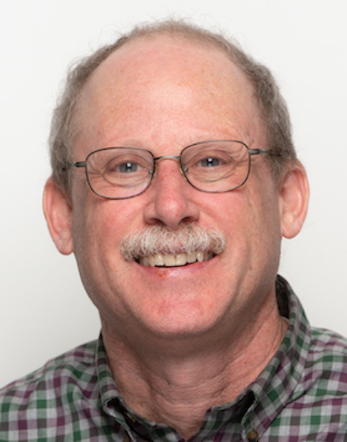

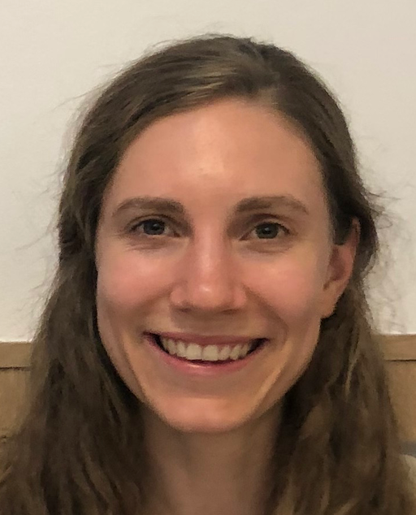

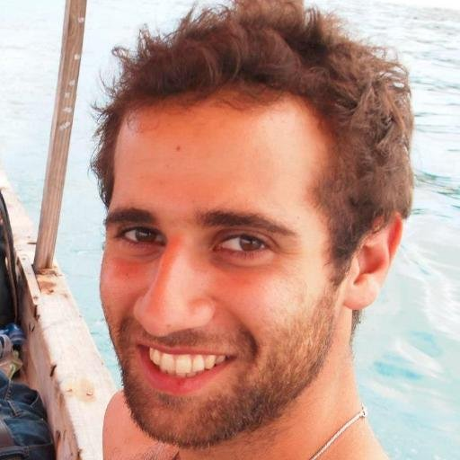

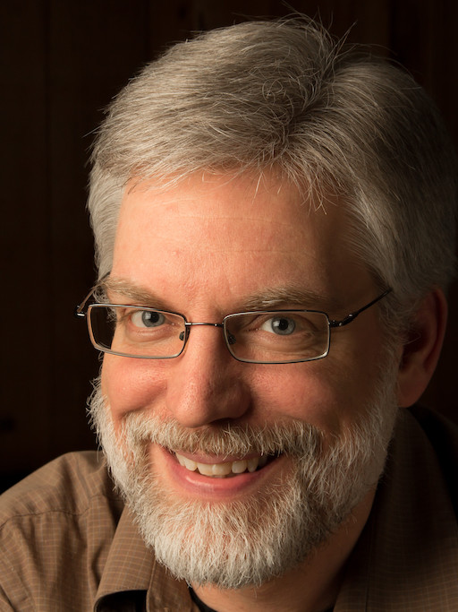

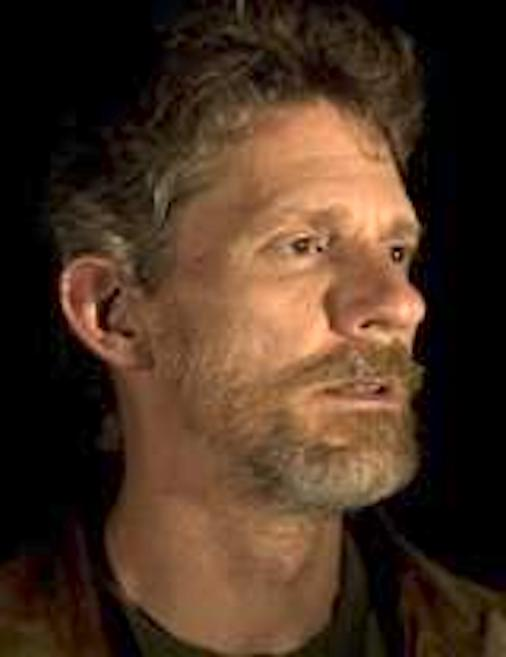

## Danny Kaplan

- Professor of Applied Math and Statistics at Macalester College
- First use of R in a classroom in Western Hemisphere (likely)
- First use of RStudio beyond JJ and Joe
- First client for Shiny
- Textbook Author
  - Statistical Modeling: A Fresh Approach
  - Data Computing
  - Stats for Data Science
  - Modern Data Science with R
  - Compact Guide

## Sara Altman

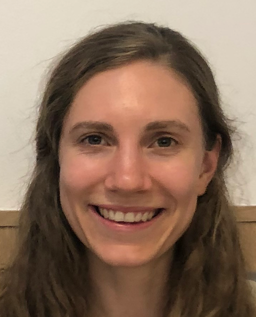

- I teach an introductory, project-based data science class at Stanford
- I create open materials and tools for learning and teaching data science and R

## Dean Attali

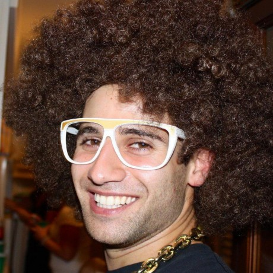

- *“I love shiny so much that I decided to make that my job.”*
- Creator of [“Shiny Case Studies”](https://www.datacamp.com/courses/building-web-applications-in-r-with-shiny-case-studies) course — an interactive, online video course
- Second highest all-time answerer in the “shiny” tag on StackOverflow
- *“If anybody needs any help with Shiny I’d be happy to talk.”*

Dean Attali, President & CEO  
AttaliTech Ltd, http://AttaliTech.com

## Randy J. Pruim

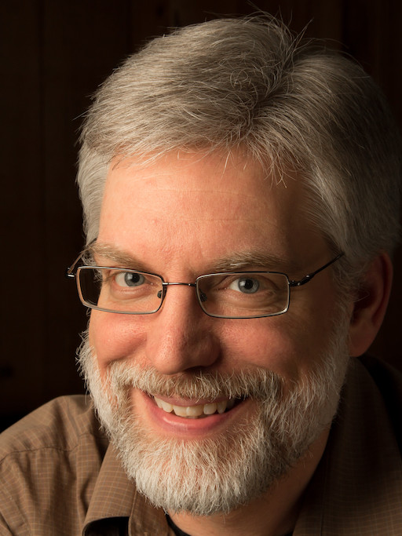

- Professor of Mathematics and Statistics at Calvin University
- Has been teaching with R since 2002
- Once knew every Rstudio employee by name — all three of them
- Maintainer of several R packages, including mosaic and ggformula
- Textbook author
  - Foundations and Applications of Statistics: An Introduction Using R
  - Gems of Theoretical Computer Science

## Homer S. White

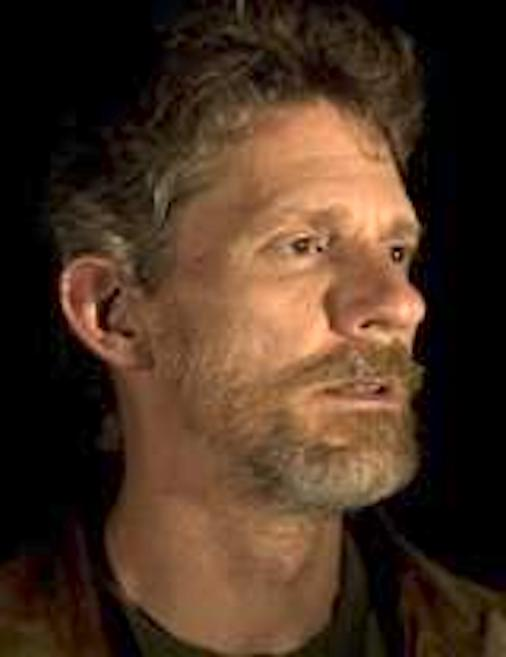

- Chair and professor of mathematics and computer science at, Georgetown College, a small liberal arts college in Kentucky.
- Teaches introductory computer science and data science with R
- Author of several R packages used in the teaching of undergraduate statistics
- Early enthusiast of Shiny.

Contact: 502-863-8307 `Homer_White@georgetowncollege.edu`